# When a neuron changes its response — tutorial reading preview

**Static preview:** this page shows the teaching text and starter code. To edit exercises, receive feedback, use sliders or save answers, open the R project and run `source("scripts/run_pilot.R")`. This preview has no live controls.

## Welcome: you are the analysis team

GABA is the brain’s main inhibitory neurotransmitter. When GABA activates GABA_A receptors, their channels allow anions, mainly chloride, to cross the membrane. The chloride gradient helps determine the voltage towards which that current drives the neuron: the **GABA reversal potential (E_GABA)**. At that voltage the net GABA_A current is zero; on either side it flows in opposite directions.

Imagine a neuron resting at −65 mV. If E_GABA is −80 mV, opening these channels tends to make its voltage more negative. If E_GABA shifts to −55 mV, the same input can instead depolarize it. Depolarizing GABA does not automatically trigger spikes: opening channels can still reduce the effect of other inputs (shunting inhibition), and spike threshold matters. Thus “less negative E_GABA” does not simply mean “a more sensitive neuron.” These example voltages illustrate the principle; they are not extra observations.

Here researchers studied **GABA neurons in the ventral tegmental area (VTA)** during cue–reward learning in rats. In one protocol a tone predicted a sugar pellet; in the control protocol tone and reward were unpaired. Recordings were made in brain slices from different animals at baseline, acquisition and plateau. Acquisition is a learning phase, not a drug treatment. The study links a temporary depolarizing E_GABA shift to reduced function of KCC2, a transporter that helps remove chloride from neurons. Our table lets us investigate the voltage pattern; by itself it cannot establish that mechanism or a change in firing.

[Experiment and methods: Woo et al., 2025](https://www.nature.com/articles/s41467-025-66838-x).

**Your question:** Does the GABA reversal potential differ between baseline and the acquisition phase of reward learning?

No previous R or statistics is needed. First we will learn to run a command, then follow the measurements into a figure. You are allowed to be surprised by the data. A result that does not support your prediction is still a result worth explaining.

Work in pairs. One person types and the other predicts or explains; swap after each section. Keep your own written answers. We start with a quick command warm-up, then meet all the animals and their cells. Replication will guide our selections, summaries and plots. Day 1 includes guided statistics in RStudio; day 2 is your independent project.

- **Code editor:** type R commands in the box containing code. Click **Run Code** to see results below it.
- **Answer box:** type your scientific explanation in ordinary words.
- **Submit Answer:** save your current code attempt and request feedback. Run Code alone does not save an attempt for download.

Keep the supplied commands and **append your solution underneath**, unless a task explicitly asks you to repair an error. Each editor runs independently: keep its supplied import lines. `#` starts a comment, which R ignores. You can experiment without changing the source data files.

Download regularly. Written answers are session-only; download before closing or reloading. Your notebook contains your submitted code, your explanations and your current slider views. It will become an ordinary editable R notebook in RStudio.

## 1. First successful runs — 5 minutes

Click inside the editor and press Enter for a new line. Running an editor runs every line, top to bottom. Output appears in the same order. The printed `[1]` marks the position of the first output item; it is not part of the calculated number.

### Make R do the arithmetic

Run the supplied addition. Then append `12 / 4` on a new line, run again and submit. `/` means divide.

```r
2 + 3

# Add your command below.
```

### Plan the plate

Three plates, four wells each: how many wells? Predict first. Append `3 * 4`; `*` means multiply.

```r
3 + 4

# Add your command below.
```

### Give a result a name

An **object** is information kept under a name. Read `wells <- 12` as “store 12 in wells”. The arrow is `<` followed by `-`. A name on its own displays its value. Keep the example, then append `wells <- 16` and `wells` on separate lines.

```r
wells <- 12
wells
```

### Keep several measurements together: c()

`c()` combines values into a **vector**, an ordered collection. A **function** is a named operation; its inputs go inside parentheses. In `c(2, 4, 6)`, commas separate three values. Nothing is being added yet! Run the example. Then append `counts <- c(2, 4, 6, 8)` and `counts` to keep and display four values.

```r
counts <- c(2, 4, 6)
counts
```

### An average in two ways: mean()

The **mean** is the sum divided by the number of observations. The example calculates it by hand. Append `mean(counts)`: give the stored vector to the function by putting its name inside parentheses. Does it agree? `length(counts)` reports how many values there are, not their average.

```r
counts <- c(2, 4, 6)
(2 + 4 + 6) / 3
length(counts)
```

### Predict before you press Run

These are made-up assay readings. Before running, predict whether adding 9 will raise or lower the mean. Keep the example and append a new vector containing 4, 5, 6, 9, then calculate its mean. Explain the change to your partner.

```r
readings <- c(4, 5, 6)
mean(readings)
```

### Recover from a small error

Run this editor once. R names are case-sensitive: `Readings` and `readings` are different. Repair the capital letter and rerun. In RStudio, a Console prompt of `+` means an unfinished command; press Esc, then repair and rerun the complete command in your notebook.

```r
readings <- c(4, 5, 6)
mean(Readings)
```

## 2. Meet the data — 20 minutes

We have **26 rats and 47 recorded cells**, across two conditioning protocols and three learning phases. We will inspect both levels before selecting a comparison.

- `investigation.csv`: one row per rat, with its mean voltages and `n_cells`.
- `replicates.csv`: one row per recorded cell, with the rat ID it belongs to.
- `sample_id`: a readable label, `Rat_01` to `Rat_26`. It is not a measurement or a rank. The original labels remain in `data/animal_id_key.csv`.
- `conditioning`: Paired (tone predicts reward) or Unpaired (control protocol).
- `phase`: Baseline, Acquisition or Plateau; `day_label` records the source day label.
- `reversal_mV` and `resting_mV`: GABA reversal and resting membrane potentials, in millivolts. In the animal table these are means of the recorded cells; in the cell table they are individual cell measurements.

A table in R is a **data frame**. Its columns are variables. Conditioning is **nominal**: categories without a ranking. Learning phase has an **order**, but equal steps between phase labels do not represent equal amounts of learning. Voltage is a **continuous** measurement. Biological meaning matters more than whether a value contains digits.

The source workbook has ten paired plateau cells while the paper caption reports nine. We retain the workbook observations and flag the discrepancy; the baseline/acquisition comparison is unaffected. See `data/dictionary.html` in the course project for the preparation details.

### Open the table

`read.csv()` reads a comma-separated table. Quotes mark literal text, including a file path. `<-` stores the table as animals. `head()` previews rows, `names()` lists columns, and `dim()` reports rows then columns. Run the supplied import, then append `head(animals)`, `names(animals)` and `dim(animals)` in that order.

```r
animals <- read.csv("data/investigation.csv")
```

**Pause and explain:** row. Write your answer in the live tutorial.

### Every animal, every recorded cell

Open either table below. Find a rat in the first table and all its cells in the second. Does every rat contribute the same number of cells? These are all animals in this electrophysiology table, not every animal in the publication.

**Show all 26 animals**

| sample_id | conditioning | phase | day_label | reversal_mV | resting_mV | n_cells |
| --- | --- | --- | --- | --- | --- | --- |
| Rat_01 | Paired | Baseline | 1 | -73.85000 | -60.15000 | 1 |
| Rat_02 | Paired | Baseline | 1 | -84.48682 | -56.83034 | 2 |
| Rat_03 | Paired | Baseline | 1 | -76.01080 | -70.75610 | 1 |
| Rat_04 | Paired | Baseline | 1 | -75.73190 | -59.34840 | 1 |
| Rat_05 | Paired | Baseline | 1 | -78.74960 | -45.29000 | 2 |
| Rat_06 | Paired | Baseline | 1 | -74.72376 | -51.49626 | 1 |
| Rat_07 | Paired | Baseline | 1 | -83.23353 | -61.87500 | 1 |
| Rat_08 | Paired | Acquisition | 7 | -57.01000 | -58.05990 | 3 |
| Rat_09 | Paired | Acquisition | 7 | -57.13725 | -57.43870 | 2 |
| Rat_10 | Paired | Acquisition | 7 | -54.79740 | -64.17830 | 2 |
| Rat_11 | Paired | Acquisition | 7 | -59.84615 | -59.32755 | 1 |
| Rat_12 | Paired | Acquisition | 7 | -62.55144 | -50.47872 | 1 |
| Rat_13 | Paired | Acquisition | 7 | -59.87206 | -55.03394 | 3 |
| Rat_14 | Paired | Plateau | 13 | -76.92710 | -59.26510 | 2 |
| Rat_15 | Paired | Plateau | 13 | -79.25440 | -67.04110 | 1 |
| Rat_16 | Paired | Plateau | 13 | -76.53647 | -64.42670 | 3 |
| Rat_17 | Paired | Plateau | 13 | -71.85102 | -61.69739 | 3 |
| Rat_18 | Paired | Plateau | 13 | -80.12422 | -73.82550 | 1 |
| Rat_19 | Unpaired | Baseline | 1 | -74.04130 | -45.43689 | 1 |
| Rat_20 | Unpaired | Baseline | 1 | -77.74965 | -52.02211 | 2 |
| Rat_21 | Unpaired | Baseline | 1 | -76.90392 | -57.30718 | 2 |
| Rat_22 | Unpaired | Acquisition | 7 | -79.71530 | -60.62718 | 1 |
| Rat_23 | Unpaired | Acquisition | 7 | -79.16306 | -53.76188 | 3 |
| Rat_24 | Unpaired | Acquisition | 7 | -78.65908 | -52.96614 | 3 |
| Rat_25 | Unpaired | Plateau | 13 | -75.39141 | -41.75733 | 2 |
| Rat_26 | Unpaired | Plateau | 13 | -80.14266 | -54.60971 | 2 |

**Show all 47 cells, grouped by animal ID**

| sample_id | record_number | conditioning | phase | reversal_mV | resting_mV |
| --- | --- | --- | --- | --- | --- |
| Rat_01 | 1 | Paired | Baseline | -73.85000 | -60.15000 |
| Rat_02 | 1 | Paired | Baseline | -86.38743 | -63.94558 |
| Rat_02 | 2 | Paired | Baseline | -82.58620 | -49.71510 |
| Rat_03 | 1 | Paired | Baseline | -76.01080 | -70.75610 |
| Rat_04 | 1 | Paired | Baseline | -75.73190 | -59.34840 |
| Rat_05 | 1 | Paired | Baseline | -81.63920 | -46.09000 |
| Rat_05 | 2 | Paired | Baseline | -75.86000 | -44.49000 |
| Rat_06 | 1 | Paired | Baseline | -74.72376 | -51.49626 |
| Rat_07 | 1 | Paired | Baseline | -83.23353 | -61.87500 |
| Rat_08 | 1 | Paired | Acquisition | -46.30000 | -56.75480 |
| Rat_08 | 2 | Paired | Acquisition | -65.50460 | -59.42200 |
| Rat_08 | 3 | Paired | Acquisition | -59.22540 | -58.00290 |
| Rat_09 | 1 | Paired | Acquisition | -57.33020 | -53.04070 |
| Rat_09 | 2 | Paired | Acquisition | -56.94430 | -61.83670 |
| Rat_10 | 1 | Paired | Acquisition | -51.53640 | -63.64030 |
| Rat_10 | 2 | Paired | Acquisition | -58.05840 | -64.71630 |
| Rat_11 | 1 | Paired | Acquisition | -59.84615 | -59.32755 |
| Rat_12 | 1 | Paired | Acquisition | -62.55144 | -50.47872 |
| Rat_13 | 1 | Paired | Acquisition | -52.64151 | -62.71186 |
| Rat_13 | 2 | Paired | Acquisition | -64.78873 | -49.29078 |
| Rat_13 | 3 | Paired | Acquisition | -62.18593 | -53.09917 |
| Rat_14 | 1 | Paired | Plateau | -75.87680 | -56.84770 |
| Rat_14 | 2 | Paired | Plateau | -77.97740 | -61.68250 |
| Rat_15 | 1 | Paired | Plateau | -79.25440 | -67.04110 |
| Rat_16 | 1 | Paired | Plateau | -76.54320 | -56.16860 |
| Rat_16 | 2 | Paired | Plateau | -76.48840 | -72.61780 |
| Rat_16 | 3 | Paired | Plateau | -76.57780 | -64.49370 |
| Rat_17 | 1 | Paired | Plateau | -70.81081 | -58.75912 |
| Rat_17 | 2 | Paired | Plateau | -74.87923 | -56.52174 |
| Rat_17 | 3 | Paired | Plateau | -69.86301 | -69.81132 |
| Rat_18 | 1 | Paired | Plateau | -80.12422 | -73.82550 |
| Rat_19 | 1 | Unpaired | Baseline | -74.04130 | -45.43689 |
| Rat_20 | 1 | Unpaired | Baseline | -76.87861 | -55.72254 |
| Rat_20 | 2 | Unpaired | Baseline | -78.62069 | -48.32168 |
| Rat_21 | 1 | Unpaired | Baseline | -78.20647 | -63.85246 |
| Rat_21 | 2 | Unpaired | Baseline | -75.60137 | -50.76190 |
| Rat_22 | 1 | Unpaired | Acquisition | -79.71530 | -60.62718 |
| Rat_23 | 1 | Unpaired | Acquisition | -78.72340 | -53.55372 |
| Rat_23 | 2 | Unpaired | Acquisition | -83.45865 | -64.92147 |
| Rat_23 | 3 | Unpaired | Acquisition | -75.30713 | -42.81046 |
| Rat_24 | 1 | Unpaired | Acquisition | -71.16071 | -42.60870 |
| Rat_24 | 2 | Unpaired | Acquisition | -79.60526 | -53.85878 |
| Rat_24 | 3 | Unpaired | Acquisition | -85.21127 | -62.43094 |
| Rat_25 | 1 | Unpaired | Plateau | -74.58194 | -38.10811 |
| Rat_25 | 2 | Unpaired | Plateau | -76.20087 | -45.40655 |
| Rat_26 | 1 | Unpaired | Plateau | -79.56522 | -52.56917 |
| Rat_26 | 2 | Unpaired | Plateau | -80.72009 | -56.65025 |

### Two lab members, two sample sizes

One colleague says: “We have 47 observations.” Another says: “We have 26 rats.” They are looking at the same experiment. **Can they both be right?** Write your prediction on paper or tell your partner before opening the larger table.

Open `replicates.csv`, where a row is one recorded cell. We begin with all experimental groups. Do not choose a statistical test yet. First find out what was actually replicated.

### Count measurements, then count animals

`nrow()` counts table rows. `unique()` keeps each distinct ID once; it does not average or remove measurements from the source. Work in short steps: append `measurement_n <- nrow(replicates)`, then `animal_ids <- unique(replicates$sample_id)`, then `animal_n <- length(animal_ids)`. Display both counts on separate lines.

```r
replicates <- read.csv("data/replicates.csv")
head(replicates)
```

**Pause and explain:** replication_count. Write your answer in the live tutorial.

### Reveal: what was repeated?

The rat study recorded several cells from some animals. Different cells are real biological observations, but cells from the same rat share their animal and experimental history. For our comparison across animals, cells are **nested within rats**: several observations belong to one biological unit. Our animal table averages the recorded cells within each rat. A rat with three recorded cells still contributes one animal mean.

A **biological replicate** is an independent biological unit relevant to the question. The **experimental unit** is the unit independently assigned to an experimental condition. Repeated readings of the same sample are **technical replicates**; multiple cells within an animal are biological subsamples, not simply repeated instrument readings. These distinctions come from the experimental design, not from how many spreadsheet rows appear.

For our animal-level question, the animal is the biological unit we retain. A unique ID alone does not prove independence: shared litters, cages, treatments or batches may matter. If a treatment were assigned to whole cages, for example, counting every animal as an independent treatment replicate could still be wrong.

## 3. Follow one group — 20 minutes

First follow the cells from one rat; then select an experimental group. We will use one mean per rat for the animal-level comparison, so animals with more recorded cells do not receive extra weight.

### Follow rat Rat_08

The supplied selection keeps every reading belonging to one animal. Run it, then append `one_animal_n <- nrow(one_animal)` and display the count. Append this supplied plot to inspect the readings. `record_number` is a record index, **not time**.

```r
plot(one_animal$record_number, one_animal$reversal_mV, pch=19,
     xlab="Record within one animal (not time)", ylab="Cell GABA reversal potential (mV)")
```

```r
replicates <- read.csv("data/replicates.csv")
head(replicates)
one_animal <- replicates[replicates$sample_id == "Rat_08", ]
one_animal
```

**Pause and explain:** replication_animal. Write your answer in the live tutorial.

### Select a focused biological comparison

The full table includes several questions. For this worked example, `study.csv` contains the **13 rats** in the Paired protocol at Baseline (7) and Acquisition (6), each summarised by its recorded cells. It is a selected part of the 26-rat table you just inspected. The `group` column names the learning phase. “Paired” describes tone–reward timing; baseline and acquisition are different rats, not before-and-after measurements of the same rat.

`study$reversal_mV` retrieves the measurement column. `study$group == "Baseline"` asks a yes/no question for each row. **Two equals signs compare; `<-` assigns.** Square brackets keep the values whose group comparison is TRUE. The selection code is supplied: you need to explain and adapt it, not memorise it.

The name `baseline_reversal_mV` tells us both the biological measurement and its group. We will use `acquisition_reversal_mV` for the other group. Descriptive names help you check which animals a calculation includes.

### Follow the Acquisition animals

Run the Baseline example. Append a selection for `"Acquisition"`, store it as `acquisition_reversal_mV`, then append `length(acquisition_reversal_mV)` and `mean(acquisition_reversal_mV)`. Say which animals contributed before reading the mean.

```r
study <- read.csv("data/study.csv")
baseline_reversal_mV <- study$reversal_mV[study$group == "Baseline"]
length(baseline_reversal_mV)
mean(baseline_reversal_mV)
```

**Pause and explain:** selection. Write your answer in the live tutorial.

### Return to our actual biological question

The larger file contains other experimental groups. We must select the original comparison before reporting its sample size. The filtering code is supplied; `&` means both conditions must hold. The extra readings below must lead back to the same animals we started with.

### Defend the n in your report

Run the supplied selection and read the measurement counts. Append `n_baseline <- length(baseline_ids)` and `n_acquisition <- length(acquisition_ids)`, then display both. Explain why the animal counts—not the number of assay or cell rows—belong in our original animal-level comparison.

```r
replicates <- read.csv("data/replicates.csv")
comparison_readings <- replicates[replicates$conditioning == "Paired" & replicates$phase != "Plateau", ]
table(comparison_readings$phase) # Measurement counts, not animal counts.
baseline_ids <- unique(comparison_readings$sample_id[comparison_readings$phase == "Baseline"])
acquisition_ids <- unique(comparison_readings$sample_id[comparison_readings$phase == "Acquisition"])
```

**Pause and explain:** replication_report. Write your answer in the live tutorial.

**Your final recommendation to the lab:** “Our comparison contains ___ and ___ biological units. Additional readings tell us *, but do not independently replicate* . Before choosing an analysis I would check ___.” Exchange recommendations with your partner.

For this teaching comparison we use one mean per animal, giving each animal equal weight. A hierarchical model can retain cell-level variation while representing cells within rats. It is an extension, not a command you need to learn today.

**Bridge to inference:** before asking whether two means differ, ask what independently replicates the comparison. A smaller p-value cannot repair the wrong sample unit.

## 4. Typical values, variation and an awkward reading — 10 minutes

The mean gives each observation equal weight. The **median** is the middle of the ordered observations (the mean of the two middle ones when there is an even number). The **sample standard deviation (SD)** describes variation among observations, in the same units as the measurement. A larger SD means more variation; it does not by itself tell us how uncertain the mean is. Sample size also matters for that.

### Which group varies more?

Run the supplied mean and median calculations. Append `sd_baseline_reversal_mV <- sd(baseline_reversal_mV)` and `sd_acquisition_reversal_mV <- sd(acquisition_reversal_mV)`, then display each named result on its own line. Compare the SDs in your answer.

```r
study <- read.csv("data/study.csv")
baseline_reversal_mV <- study$reversal_mV[study$group == "Baseline"]
acquisition_reversal_mV <- study$reversal_mV[study$group == "Acquisition"]
mean(baseline_reversal_mV)
median(baseline_reversal_mV)
mean(acquisition_reversal_mV)
median(acquisition_reversal_mV)
```

**Pause and explain:** spread. Write your answer in the live tutorial.

### Challenge: double the headline

A colleague reports that “the average response doubled”. Four of five made-up culture readings are fixed at 4, 5, 5 and 6. Only the fifth reading can change. Can you double the original mean without changing the median? Work out a candidate before moving the slider. These are separate invented readings, not edits to our animal measurements.

### Test the headline in code

Keep the original readings. Append a new assay vector with your chosen fifth value, then `new_mean <- mean(assay)` and `new_median <- median(assay)`. Display both results. Bonus: with the other four readings fixed, which median values are even possible?

```r
assay <- c(4, 5, 5, 6, 7)
mean(assay)
median(assay)
```

**Pause and explain:** outlier. Write your answer in the live tutorial.

## 5. The assay that failed — 5 minutes

`NA` means missing. It does not mean zero. Imagine one assay failed: would writing zero describe what happened? First predict what R should do when a required input is unknown. Then compare two decisions using these invented values; keep the source table untouched.

### Missing is a different claim from zero

Run the starter: `mean(example)` returns NA. Count the recorded numbers by looking at the vector. Append `observed_n <- 3` and `observed_mean <- mean(example, na.rm = TRUE)`. The comma introduces another argument; `na.rm = TRUE` excludes missing entries for this calculation only. In a separate vector called `zero_example`, use 0 instead of NA; calculate `zero_mean <- mean(zero_example)`. Display the count and both means.

```r
example <- c(4, 6, NA, 8)
mean(example)
observed_n <- length(example) # Change: count observed values, excluding NAs
```

**Pause and explain:** missing. Write your answer in the live tutorial.

Excluding a missing value does not recover it. If high values fail more often, the observed values may systematically miss the high end of the distribution.

**Take a 15-minute break.** On return, swap typing and explanation roles.

## 6. How many bars tell the story? — 15 minutes

A **histogram** groups measurements into intervals called bins. Bar height counts observations inside each interval. A few broad bins can hide structure; many narrow bins can make a small sample look full of gaps. Neither setting adds information. The marks below the bars show where the actual observations lie. All six panels use the same bins and axes. Bin boundaries also stay fixed when you switch between animal means and cells.

The explorer uses **all 26 rats or all 47 cells**, separated by protocol and learning phase. Choose **Individual cells** to see the original cell measurements; choose **Animal means** to give each rat one observation. Panel titles report both counts. Cells within one rat share its experimental history, so switching views does not add independent animals. Some panels remain small even with the complete dataset.

Compare the two views within one panel first. Which rats contribute more dots in the cell view? Why might cell and animal summaries differ? The source’s plateau cell-count discrepancy described earlier also applies here.

Try to make the data look as smooth as possible, then as irregular as possible. Ask your partner which biological conclusions survive both views. This is a challenge to the display, not an invitation to select whichever plot supports your preferred story.

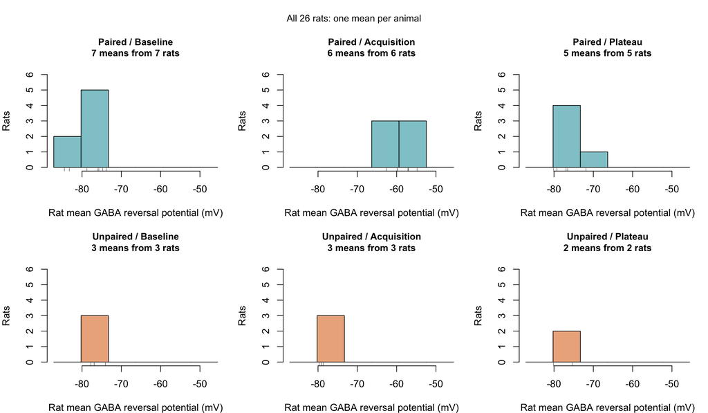

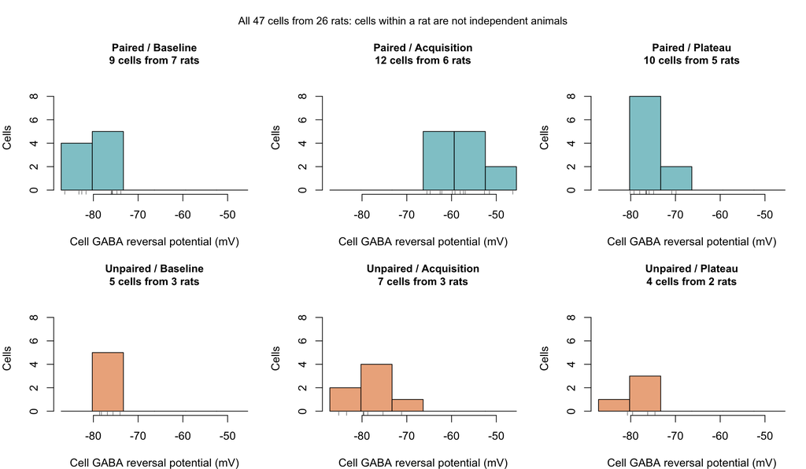

### Code practice: the selected baseline/acquisition comparison

The explorer above uses all six groups. This short editor deliberately returns to `study.csv`: seven Baseline rat means and six Acquisition rat means from the Paired protocol. Its plots are separate from the explorer, and moving the explorer controls does not change this code.

`hist()` draws a histogram. `breaks = 5` requests roughly five bins; base R chooses convenient boundaries, so the actual count can differ. The slider above uses exact boundaries. `main` sets the title and `xlab` labels the horizontal axis. Keep the Baseline example and append `hist_acquisition_reversal_mV <- hist(acquisition_reversal_mV, breaks = 5, main = "Acquisition", xlab = "Mean GABA reversal potential (mV)")`.

```r
study <- read.csv("data/study.csv")
baseline_reversal_mV <- study$reversal_mV[study$group == "Baseline"]
acquisition_reversal_mV <- study$reversal_mV[study$group == "Acquisition"]
hist(baseline_reversal_mV, breaks=5, main="Baseline", xlab="Mean GABA reversal potential (mV)")
```

**Pause and explain:** histogram. Write your answer in the live tutorial.

## 7. Show the animals behind the average — 20 minutes

`factor()` below fixes the display order so colours and group positions stay consistent across figures. It does not change any measurements.

A **boxplot** puts the middle half of the observations inside a box. The line is the median. Whiskers extend to observations within 1.5 box lengths of the box; more distant observations are conventionally drawn separately. These points deserve investigation, not automatic deletion. With small samples, always look at the actual observations as well.

In R’s plot formula `reversal_mV ~ group`, read `~` as “shown by group”. `data = study` tells R where those column names live. `stripchart()` adds individual observations. Jitter moves points sideways slightly to reveal overlap; it never changes their measured height. `set.seed(7)` makes that sideways movement repeatable.

### Can the mean-only chart tell the whole story?

Run the supplied bar chart, which shows only two means. Append the following worked template to add a boxplot with all animals. Run, inspect and submit. You do not need to invent the plotting syntax.

```r
study$group <- factor(study$group, levels=c("Baseline","Acquisition"))
comparison <- boxplot(reversal_mV ~ group, data=study, outline=FALSE,
  ylab="Mean GABA reversal potential (mV)", xlab="Group", col=c("lightblue","peachpuff"))
set.seed(7)
stripchart(reversal_mV ~ group, data=study, vertical=TRUE, method="jitter",
  jitter=0.1, add=TRUE, pch=16)
```

```r
study <- read.csv("data/study.csv")
baseline_reversal_mV <- study$reversal_mV[study$group == "Baseline"]
acquisition_reversal_mV <- study$reversal_mV[study$group == "Acquisition"]
barplot(c(mean(baseline_reversal_mV),mean(acquisition_reversal_mV)),names.arg=c("Baseline","Acquisition"),
  ylab="Mean: Mean GABA reversal potential (mV)",main="Only the means")
```

**Pause and explain:** boxplot. Write your answer in the live tutorial.

### A smooth violin from a small sample?

A violin’s width estimates where measurements are more concentrated. The dots are observed; the smooth outline is calculated. Each violin here has equal maximum width and stops at its observed range; width does not encode sample size or a confidence interval. The short line is the median. Change the smoothing: can you make a bump vanish without changing a single animal?

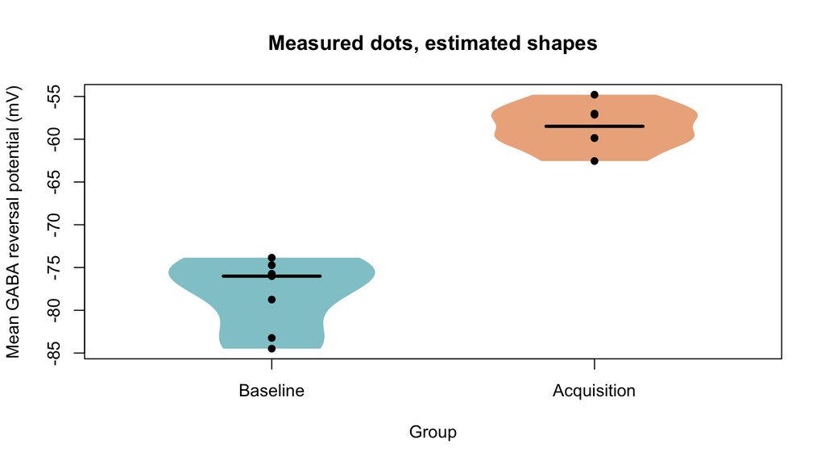

Change smoothing in the live tutorial and explain what is estimated.

### Give the dots their owners

The next display uses a small selection of animals **from the same condition** so the plot stays readable. First look at the pooled cloud. Then reveal animal IDs. The vertical positions and the number of measurements stay fixed; the revealed groups show which observations share an animal. Compare variation within an animal with differences between animals. This small view illustrates the structure; it does not establish the structure of the entire population.

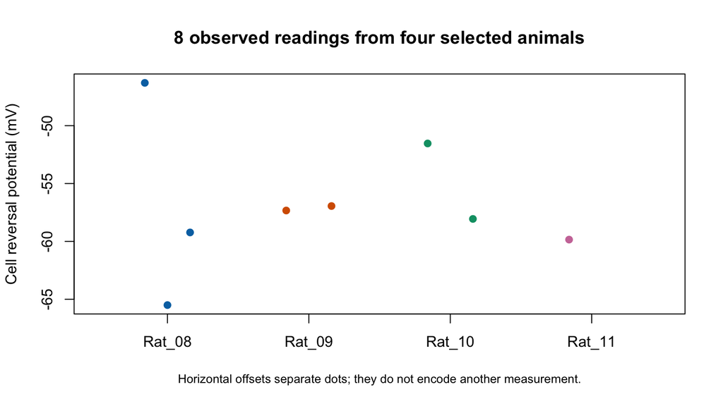

### The copy-and-paste experiment: can we manufacture precision?

Predict what will happen if we copy every row of the original comparison’s reference group five times. Will the mean change? Will the number of animals change? Could a computer be fooled by the larger row count?

This is a **deliberately incorrect analysis of duplicated rows**, using the small animal-level table from earlier. No new assays, cells or animals are collected. The source files stay intact. This exaggerated example exposes an assumption; real repeated measurements need not be identical.

The **standard error (SE)** describes uncertainty in an estimated mean under a statistical model; it is different from the SD describing spread among observations. A familiar SE calculation, `SD / sqrt(n)`, assumes independent observations. The solid line below deliberately breaks that assumption by pretending copied rows are independent. The dashed reference uses the original animal-level values and stays fixed. It too relies on the original animals being independent.

```
##   Rows Distinct_animals      Mean  Naive_SE Animal_SE
## 1   35                7 -78.11234 0.6705061  1.596124
```

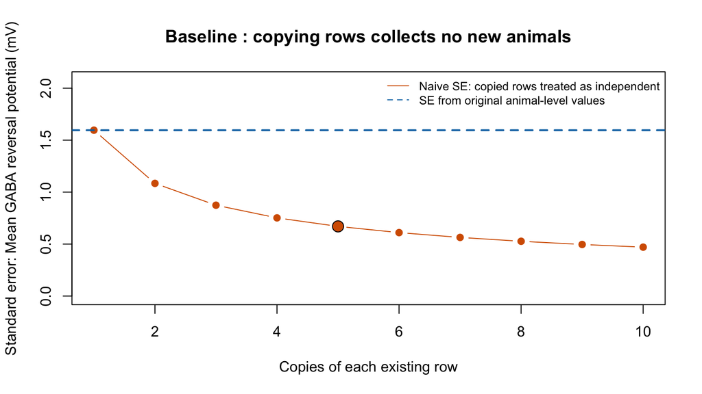

This mistake is called **pseudoreplication**: treating dependent observations as if they independently replicated the biological comparison. Extra readings can help estimate measurement variability or characterise an animal better. They cannot substitute for collecting additional independent biological replicates. A sophisticated statistical model must still respect that structure.

## 8. Two measurements from the same animal — 10 minutes

The source sheet records both voltages for the same identified cell. We average each voltage over the same cells within each rat: the two coordinates of a point therefore belong to **the same rat**. This is legitimate matching within a row. By contrast, a baseline rat and an acquisition rat are different animals and must not be matched by row position.

The question here is exploratory: within one learning phase, do rats with less negative mean E_GABA also have less negative resting potential? The two voltages describe different properties, so an association is not guaranteed. A weak pattern with six or seven rats is inconclusive; a correlation cannot establish chloride regulation or causation.

A **scatterplot** gives each animal one point. Its horizontal and vertical positions show two different measurements from that animal. A rising pattern suggests positive association; a falling pattern suggests negative association. First inspect a single group, so a difference between groups is not mistaken for a relationship within a group.

### Does the pattern travel to the other group?

In `study[condition, ]`, the part before the comma selects rows and the blank after it keeps all columns. Run the supplied Baseline plot. Append the same three commands for Acquisition, naming the selected table `acquisition_rats`. Keep the same measurement axes and label the group.

```r
study <- read.csv("data/study.csv")
baseline_rats <- study[study$group == "Baseline", ]
plot(baseline_rats$reversal_mV, baseline_rats$resting_mV,
  xlab="Mean GABA reversal potential (mV)", ylab="Mean resting membrane potential (mV)", main="Baseline", pch=19)
```

**Pause and explain:** scatter. Write your answer in the live tutorial.

## 9. Your own notebook — 5 minutes

1. Submit after your final edits, then download. Save the file in the project’s `notebooks/` folder.
2. Open that Rmd in RStudio. **Source editor:** saved code and written explanations. **Console:** temporary execution and messages. **Environment:** temporary objects created by running code.
3. In Session → Restart R, clear those temporary objects. Run the setup chunk with its green triangle, then run the remaining chunks in order. Ctrl+Enter (Windows/Linux) or Cmd+Enter (Mac) runs the current line; the chunk’s green triangle runs the whole chunk.
4. Type your prose outside code chunks. Keep the opening and closing chunk fences. Click **Knit** to make an HTML notebook. Knit starts a fresh R session; it cannot use objects created only in your Console.
5. Check the rendered HTML for errors, missing explanations and unfinished tasks. A successful Knit is not proof of a complete analysis.

Continue with `notebooks/03_statistical_analysis.Rmd` in RStudio. Day 2 uses `notebooks/04_investigation.Rmd`. Keep your Rmd source and submit the final HTML to the learning system. On a shared computer, save your download and use **Start Over** before the next student.

## Extra: the middle half

Quartiles split ordered data into four parts. The interquartile range, IQR, is the upper quartile minus the lower quartile. Try `quantile(baseline_reversal_mV)`, `IQR(baseline_reversal_mV)` and `range(baseline_reversal_mV)` in your downloaded notebook after creating `baseline_reversal_mV`. Explain why the range is especially sensitive to a single extreme value. With small samples, software conventions for quartiles can differ.